# HW4

### Question 9.1

```r
#load factoextra library for visualization
library(factoextra)
```

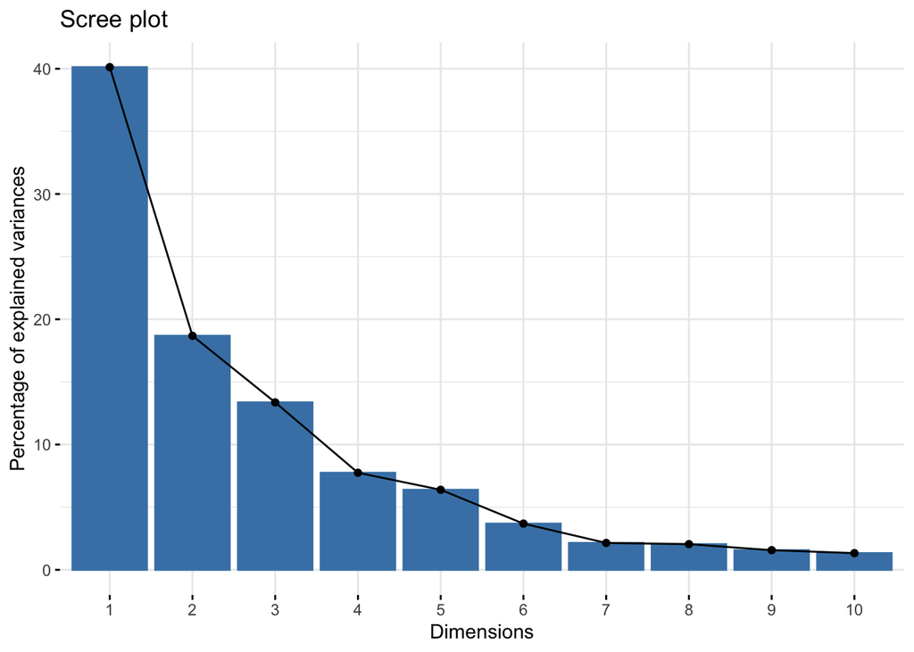

```r
#read in data and create df without response variable
crimedf <- read.table('uscrime.txt', header = TRUE)
factors <- crimedf[,-16]

#run PCA on predictor variables
pca <- prcomp(factors, scale. = TRUE )

#Scree plot to visuzalize percent of variance explained by each principal component
variances <- fviz_eig(pca)
variances
```

```r
summary(pca)
```

```
## Importance of components:
##                           PC1    PC2    PC3     PC4     PC5     PC6     PC7
## Standard deviation     2.4534 1.6739 1.4160 1.07806 0.97893 0.74377 0.56729
## Proportion of Variance 0.4013 0.1868 0.1337 0.07748 0.06389 0.03688 0.02145
## Cumulative Proportion  0.4013 0.5880 0.7217 0.79920 0.86308 0.89996 0.92142
##                            PC8     PC9    PC10    PC11    PC12    PC13   PC14
## Standard deviation     0.55444 0.48493 0.44708 0.41915 0.35804 0.26333 0.2418
## Proportion of Variance 0.02049 0.01568 0.01333 0.01171 0.00855 0.00462 0.0039
## Cumulative Proportion  0.94191 0.95759 0.97091 0.98263 0.99117 0.99579 0.9997
##                           PC15
## Standard deviation     0.06793
## Proportion of Variance 0.00031
## Cumulative Proportion  1.00000
```

These visualizations show the percentage of the variance explained by each principal component. This gives me an idea of how many principal components i should include in my regression.

I’ll start with the first 6 principal components since they 90% of the variance in the data.

```r
#concatenate response with first 6 Principal Components
firstsix <- pca$x[ ,1:6]
sixandresponse = data.frame(cbind(firstsix,Crime = crimedf[,16]))
head(sixandresponse)
```

```
##         PC1        PC2         PC3         PC4         PC5        PC6 Crime
## 1 -4.199284 -1.0938312 -1.11907395  0.67178115  0.05528338  0.3073383   791
## 2  1.172663  0.6770136 -0.05244634 -0.08350709 -1.17319982 -0.5832373  1635
## 3 -4.173725  0.2767750 -0.37107658  0.37793995  0.54134525  0.7187223   578
## 4  3.834962 -2.5769060  0.22793998  0.38262331 -1.64474650  0.7294884  1969
## 5  1.839300  1.3309856  1.27882805  0.71814305  0.04159032 -0.3940902  1234
## 6  2.907234 -0.3305421  0.53288181  1.22140635  1.37436096 -0.6922513   682
```

```r
#run linear regression using the 6 principal components as regressors
regression <- lm(Crime~.,sixandresponse)

summary(regression)
```

```
##
## Call:
## lm(formula = Crime ~ ., data = sixandresponse)
##
## Residuals:
##     Min      1Q  Median      3Q     Max
## -377.15 -172.23   25.81  132.10  480.38
##
## Coefficients:
##             Estimate Std. Error t value Pr(>|t|)
## (Intercept)   905.09      35.35  25.604  < 2e-16 ***
## PC1            65.22      14.56   4.478 6.14e-05 ***
## PC2           -70.08      21.35  -3.283  0.00214 **
## PC3            25.19      25.23   0.998  0.32409
## PC4            69.45      33.14   2.095  0.04252 *
## PC5          -229.04      36.50  -6.275 1.94e-07 ***
## PC6           -60.21      48.04  -1.253  0.21734
## ---
## Signif. codes:  0 '***' 0.001 '**' 0.01 '*' 0.05 '.' 0.1 ' ' 1
##
## Residual standard error: 242.3 on 40 degrees of freedom
## Multiple R-squared:  0.6586, Adjusted R-squared:  0.6074
## F-statistic: 12.86 on 6 and 40 DF,  p-value: 4.869e-08
```

```r
#multiply the coefficients of the regression by the rotation matrix to get the coefficients in terms of the original variables
Z <- as.matrix(regression$coefficients[-1])
V <- as.matrix(pca$rotation[,1:6])
X <- V %*% Z

#unscale the intercept and coefficients
intercept <- regression$coefficients[1]-sum(X * (pca$center /pca$scale))
coef <- X/pca$scale

#new data for prediction
new <- data.frame( M = 14.0 , So = 0.0 , Ed = 10.0 , Po1 = 12.0,
                   Po2 = 15.5 , LF = 0.640 , M.F = 94.0 , Pop = 150.0 ,
                   NW = 1.1 , U1 = 0.120 , U2 = 3.6 , Wealth = 3200.0 ,
                   Ineq = 20.1 , Prob = 0.04 , Time = 39.0 )

prediction <- intercept + (as.matrix(new) %*% coef)

prediction
```

```
##          [,1]
## [1,] 1248.427
```

I use the pcr function from the pls package to perform Primary Component Regression to confirm my answer

```r
library(pls)
pcrtest <- pcr(Crime~., data = crimedf,ncomp = 6,scale = TRUE, )

prediction <- predict(pcrtest , new, ncomp = 6)
prediction
```

```
## , , 6 comps
##
##      Crime
## 1 1248.427
```

The formula for my regression can be found as:

```
## [1] "Y =  -5923.647 + 69.892 M + 91.653 So + 18.293 Ed + 41.425 Po1 + 42.433 Po2 + 1135.641 LF + 38.216 M.F + 0.681 Pop + 9.237 NW + 100.945 U1 + 34.866 U2 + 0.047 Wealth + 1.435 Ineq + -2274.397 Prob + 5.098 Time"
```

Comparing the quality of the model to a basic regression

```r
naive <- lm(Crime~.,crimedf )
summary(naive)
```

```
##
## Call:
## lm(formula = Crime ~ ., data = crimedf)
##
## Residuals:
##     Min      1Q  Median      3Q     Max
## -395.74  -98.09   -6.69  112.99  512.67
##
## Coefficients:
##               Estimate Std. Error t value Pr(>|t|)
## (Intercept) -5.984e+03  1.628e+03  -3.675 0.000893 ***
## M            8.783e+01  4.171e+01   2.106 0.043443 *
## So          -3.803e+00  1.488e+02  -0.026 0.979765
## Ed           1.883e+02  6.209e+01   3.033 0.004861 **
## Po1          1.928e+02  1.061e+02   1.817 0.078892 .
## Po2         -1.094e+02  1.175e+02  -0.931 0.358830
## LF          -6.638e+02  1.470e+03  -0.452 0.654654
## M.F          1.741e+01  2.035e+01   0.855 0.398995
## Pop         -7.330e-01  1.290e+00  -0.568 0.573845
## NW           4.204e+00  6.481e+00   0.649 0.521279
## U1          -5.827e+03  4.210e+03  -1.384 0.176238
## U2           1.678e+02  8.234e+01   2.038 0.050161 .
## Wealth       9.617e-02  1.037e-01   0.928 0.360754
## Ineq         7.067e+01  2.272e+01   3.111 0.003983 **
## Prob        -4.855e+03  2.272e+03  -2.137 0.040627 *
## Time        -3.479e+00  7.165e+00  -0.486 0.630708
## ---
## Signif. codes:  0 '***' 0.001 '**' 0.01 '*' 0.05 '.' 0.1 ' ' 1
##
## Residual standard error: 209.1 on 31 degrees of freedom
## Multiple R-squared:  0.8031, Adjusted R-squared:  0.7078
## F-statistic: 8.429 on 15 and 31 DF,  p-value: 3.539e-07
```

```r
summary(regression)
```

```
##
## Call:
## lm(formula = Crime ~ ., data = sixandresponse)
##
## Residuals:
##     Min      1Q  Median      3Q     Max
## -377.15 -172.23   25.81  132.10  480.38
##
## Coefficients:
##             Estimate Std. Error t value Pr(>|t|)
## (Intercept)   905.09      35.35  25.604  < 2e-16 ***
## PC1            65.22      14.56   4.478 6.14e-05 ***
## PC2           -70.08      21.35  -3.283  0.00214 **
## PC3            25.19      25.23   0.998  0.32409
## PC4            69.45      33.14   2.095  0.04252 *
## PC5          -229.04      36.50  -6.275 1.94e-07 ***
## PC6           -60.21      48.04  -1.253  0.21734
## ---
## Signif. codes:  0 '***' 0.001 '**' 0.01 '*' 0.05 '.' 0.1 ' ' 1
##
## Residual standard error: 242.3 on 40 degrees of freedom
## Multiple R-squared:  0.6586, Adjusted R-squared:  0.6074
## F-statistic: 12.86 on 6 and 40 DF,  p-value: 4.869e-08
```

The R^2 for my Primary Component Regression is .66 while the R^2 for my plain linear regression is .80, indicating it is worse than plain. However I think this is misleading since both models are likely overfit.

I would like to learn strategies to investigate this further (hopefully reading some homework solutions will help). Because both models are likely overfit, and these estimates of quality are not valid, I would most likely choose the PCR model since it is simpler and still captures 90% of the variance in the training set.

### Question 10.1

#### a)

```r
library(tree)

tree <- tree(Crime~., crimedf)
summary(tree)
```

```
##
## Regression tree:
## tree(formula = Crime ~ ., data = crimedf)
## Variables actually used in tree construction:
## [1] "Po1" "Pop" "LF"  "NW"
## Number of terminal nodes:  7
## Residual mean deviance:  47390 = 1896000 / 40
## Distribution of residuals:
##     Min.  1st Qu.   Median     Mean  3rd Qu.     Max.
## -573.900  -98.300   -1.545    0.000  110.600  490.100
```

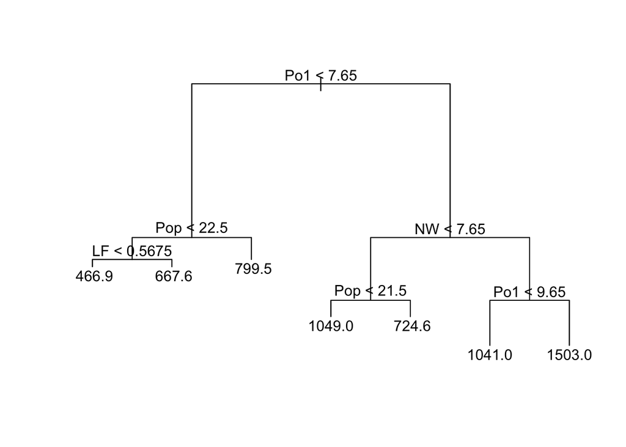

```r
plot(tree)
text(tree)
```

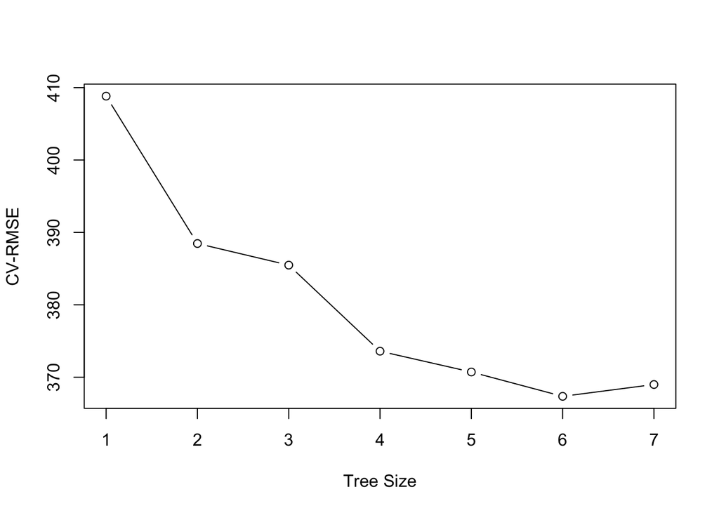

```r
set.seed(2)

tree_cv = cv.tree(tree, K = 5)
plot(tree_cv$size, sqrt(tree_cv$dev / nrow(crimedf)), type = "b",
     xlab = "Tree Size", ylab = "CV-RMSE")
```

Because the root mean squared error is minimized with Tree Size of 6 I will prune to six leaves

```r
tree_prune = prune.tree(tree, best = 6)
summary(tree_prune)
```

```
##
## Regression tree:
## snip.tree(tree = tree, nodes = 4L)
## Variables actually used in tree construction:
## [1] "Po1" "Pop" "NW"
## Number of terminal nodes:  6
## Residual mean deviance:  49100 = 2013000 / 41
## Distribution of residuals:
##     Min.  1st Qu.   Median     Mean  3rd Qu.     Max.
## -573.900  -99.520   -1.545    0.000  122.800  490.100
```

### b)

```r
library(randomForest)
#random forests


set.seed(100)
sample <- sample(nrow(crimedf), round(0.8*nrow(crimedf)), replace = FALSE)
train <- crimedf[sample,]
test <- crimedf[-sample,]

randomforest <- randomForest(Crime~.,train, ntree = 200)
summary(randomforest)
```

```
##                 Length Class  Mode
## call              4    -none- call
## type              1    -none- character
## predicted        38    -none- numeric
## mse             200    -none- numeric
## rsq             200    -none- numeric
## oob.times        38    -none- numeric
## importance       15    -none- numeric
## importanceSD      0    -none- NULL
## localImportance   0    -none- NULL
## proximity         0    -none- NULL
## ntree             1    -none- numeric
## mtry              1    -none- numeric
## forest           11    -none- list
## coefs             0    -none- NULL
## y                38    -none- numeric
## test              0    -none- NULL
## inbag             0    -none- NULL
## terms             3    terms  call
```

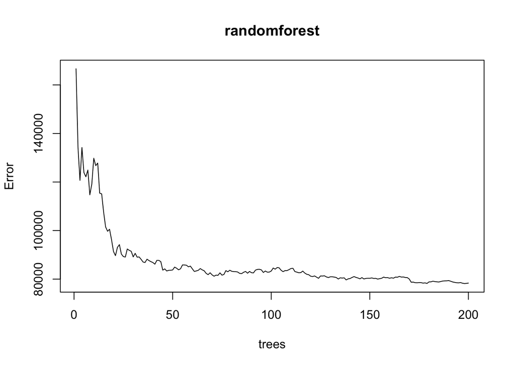

```r
plot(randomforest)
```

It looks like the error term reaches a limit after around 50 or so trees. This might be a good starting point in order to further refine the model

### Question 10.2

*Describe a situation or problem from your job, everyday life, current events, etc., for which a logistic regression model would be appropriate. List some (up to 5) predictors that you might use.*

Health professionals/statisticians could use a logistic regression to find out the odds someone would contract some disease, such as diabetes in their lifetime. Predictors could be gender, age, body mass index, blood test results, etc.

### Question 10.3

```r
# logistic regression
library(fastDummies)

#read in data
germancredit <- read.table('germancredit.txt')

#convert response variable to binary, and categorical variables to dummy binary variables
germancredit$V21[germancredit$V21 == 1] <- 0
germancredit$V21[germancredit$V21 == 2] <- 1
germancredit <- dummy_cols(germancredit, remove_selected_columns = TRUE, remove_most_frequent_dummy  = TRUE)

#create train and test set
set.seed(10)
sample <- sample(nrow(germancredit), round(0.8*nrow(germancredit)), replace = FALSE)
train <- germancredit[sample,]
test <- germancredit[-sample,]

#Create logistic model
logistic <- glm(formula = V21~. , train, family=binomial(link='logit'))


#Create confusion matrix, CM
prediction <- (predict.glm(logistic, test, type = 'response'))
threshold = .5
actual <- test$V21
pred <- round(prediction-threshold + .5)
CM <- table(actual,pred)

CM
```

```
##       pred
## actual   0   1
##      0 121  17
##      1  32  30
```

```r
cost <- CM[2,1] + 5*CM[1,2]

getcost <- function(t=.5,model = logistic, data = test) {
  prediction <- (predict.glm(model, data, type = 'response'))

  actual <- test$V21

  pred <- round(prediction-t + .5)
  CM <- table(actual,pred)

  cost <- CM[2,1] + 5*CM[1,2]

  return(cost)
}

for (i in seq(.5,.95,.01)){
  cat('Threshold:',i,'Cost:',getcost(t=i),'\n')
}
```

```
## Threshold: 0.5 Cost: 117
## Threshold: 0.51 Cost: 114
## Threshold: 0.52 Cost: 109
## Threshold: 0.53 Cost: 110
## Threshold: 0.54 Cost: 103
## Threshold: 0.55 Cost: 104
## Threshold: 0.56 Cost: 105
## Threshold: 0.57 Cost: 90
## Threshold: 0.58 Cost: 90
## Threshold: 0.59 Cost: 90
## Threshold: 0.6 Cost: 85
## Threshold: 0.61 Cost: 80
## Threshold: 0.62 Cost: 76
## Threshold: 0.63 Cost: 78
## Threshold: 0.64 Cost: 79
## Threshold: 0.65 Cost: 80
## Threshold: 0.66 Cost: 83
## Threshold: 0.67 Cost: 83
## Threshold: 0.68 Cost: 78
## Threshold: 0.69 Cost: 79
## Threshold: 0.7 Cost: 79
## Threshold: 0.71 Cost: 74
## Threshold: 0.72 Cost: 75
## Threshold: 0.73 Cost: 75
## Threshold: 0.74 Cost: 71
## Threshold: 0.75 Cost: 71
## Threshold: 0.76 Cost: 71
## Threshold: 0.77 Cost: 67
## Threshold: 0.78 Cost: 68
## Threshold: 0.79 Cost: 68
## Threshold: 0.8 Cost: 68
## Threshold: 0.81 Cost: 63
## Threshold: 0.82 Cost: 61
## Threshold: 0.83 Cost: 57
## Threshold: 0.84 Cost: 57
## Threshold: 0.85 Cost: 59
## Threshold: 0.86 Cost: 59
## Threshold: 0.87 Cost: 59
## Threshold: 0.88 Cost: 59
## Threshold: 0.89 Cost: 59
## Threshold: 0.9 Cost: 60
## Threshold: 0.91 Cost: 61
## Threshold: 0.92 Cost: 61
## Threshold: 0.93 Cost: 61
## Threshold: 0.94 Cost: 61
## Threshold: 0.95 Cost: 61
```

So I will choose a threshold of .83. My final model using this threshold can be seen below:

```r
prediction <- (predict.glm(logistic, test, type = 'response'))
threshold = .83
actual <- test$V21
pred <- round(prediction-threshold + .5)
CM <- table(actual,pred)

CM
```

```
##       pred
## actual   0   1
##      0 138   0
##      1  57   5
```

```r
cat('Accuracy on training set:', sum(diag(CM))/sum(CM))
```

[output not shown]